# Exercise 8.10

Kári Hlynsson

March 2024

We now use boosting to predict `Salary` in the `Hitters` data set.

## Part (a)

Remove the observations for whom the salary information is unknown, and then log-transform the salaries.

```r
library(ISLR2)
data(Hitters)

hitters <- Hitters[!is.na(Hitters$Salary), ]
hitters$SalaryLog <- log(hitters$Salary)

n <- nrow(hitters)
p <- ncol(hitters)
```

## Part (b)

Create a training set consisting of the first 200 observations, and a test set consisting of the remaining observations.

```r
train <- hitters[1:200, ]
test <- hitters[201:263, ]
```

## Part (c)

Perform boosting on the training set with 1,000 trees for a range of values of the shrinkage parameter $\lambda$. Produce a plot with different shrinkage values on the $x$-axis and the corresponding training set MSE on the $y$-axis.

```r
library(gbm3)

set.seed(1)

lambda <- 10^seq(-10, -0.2, by = 0.1)

out <- lapply(lambda, function(l) {
  hitters_boost_l <- gbm(
    SalaryLog ~ . - Salary,
    data = train,
    distribution = "gaussian",
    n.trees = 1000,
    shrinkage = l,
    verbose = FALSE
  )

  boost_l_pred_tr <- predict(hitters_boost_l, train, n.trees = 1000)
  boost_l_pred_ts <- predict(hitters_boost_l, test, n.trees = 1000)
  boost_l_mse_tr <- mean((boost_l_pred_tr - train$SalaryLog)^2)
  boost_l_mse_ts <- mean((boost_l_pred_ts - test$SalaryLog)^2)

  return(c(boost_l_mse_tr, boost_l_mse_ts))
})

lambda_mse <- do.call(rbind, out)

train_mse <- lambda_mse[, 1]
test_mse <- lambda_mse[, 2]
```

See part (d) for plot of training MSE.

## Part (d)

Produce a plot with different shrinkage values on the $x$-axis and the corresponding test set MSE on the $y$-axis.

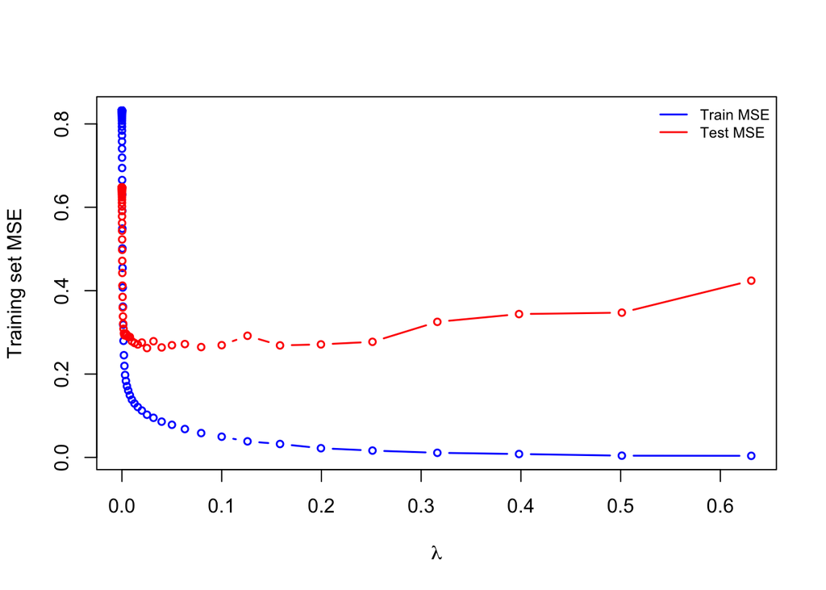

```r
dot_scale <- 0.75

plot(
  lambda,
  train_mse,
  type = "b",
  col = "blue",
  cex = dot_scale,
  xlab = expression(lambda),
  ylab = "Training set MSE",
  lwd = 1.5
)

lines(
  lambda,
  test_mse,
  type = "b",
  col = "red",
  cex = dot_scale,
  lwd = 1.5
)

legend(
  "topright",
  bty = "n",
  legend = c("Train MSE", "Test MSE"),
  col = c("blue", "red"),
  cex = dot_scale,
  lwd = 1.5
)
```

The training set MSE is decreasing with increasing values of $\lambda$ whereas the test set MSE decreases initially but starts increasing for $\lambda > 0.1$, likely due to overfitting. The optimal value for the test set MSE is

```r
lambda_opt <- lambda[which.min(test_mse)]
```

or 0.0251189. Fit this model for later use:

```r
hitters_boost <- gbm(
  SalaryLog ~ . - Salary,
  data = train,
  distribution = "gaussian",
  n.trees = 1000,
  shrinkage = lambda_opt
)

boost_mse_tr <- min(train_mse)
boost_mse_ts <- min(test_mse)
```

## Part (e)

Compare the test MSE of boosting to the test MSE that results from applying two of the regression approaches seen in Chapters 3 and 6.

Standard linear model:

```r
hitters_lm <- lm(SalaryLog ~ . - Salary, data = train)

lm_pred_tr <- predict(hitters_lm, train)
lm_mse_tr <- mean((lm_pred_tr - train$SalaryLog)^2)

lm_pred_ts <- predict(hitters_lm, test)
lm_mse_ts <- mean((lm_pred_ts - test$SalaryLog)^2)
```

Training set MSE for standard linear model is 0.3203734 and the test set MSE is 0.4917959, both higher than the counterparts provided by boosting regression trees.

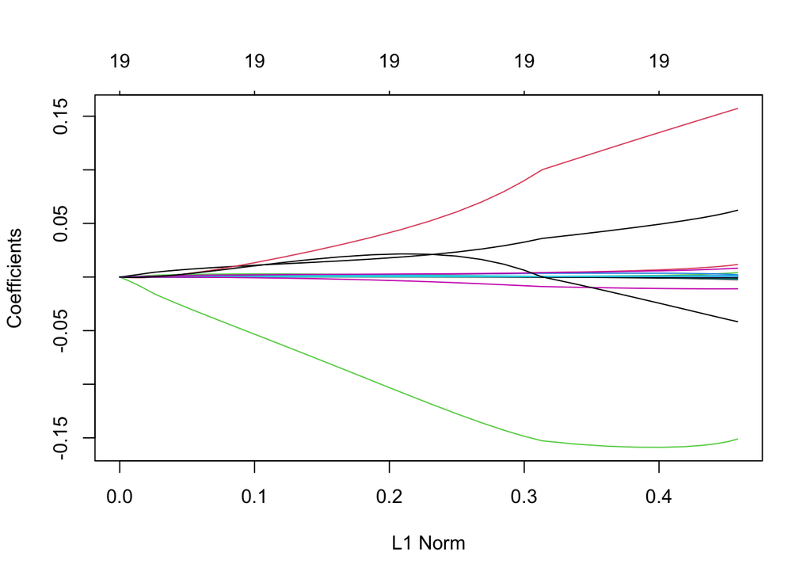

```r
library(glmnet)

l_grid <- 10^seq(10, -2, length = 100)

x_train <- model.matrix(SalaryLog ~ ., data = train[, -19])
y_train <- train$SalaryLog

x_test <- model.matrix(SalaryLog ~ ., data = test[, -19])
y_test <- test$SalaryLog

hitters_lasso <- glmnet(x_train, y_train, alpha = 0, lambda = l_grid)
plot(hitters_lasso)
```

Find the optimal shrinkage parameter value:

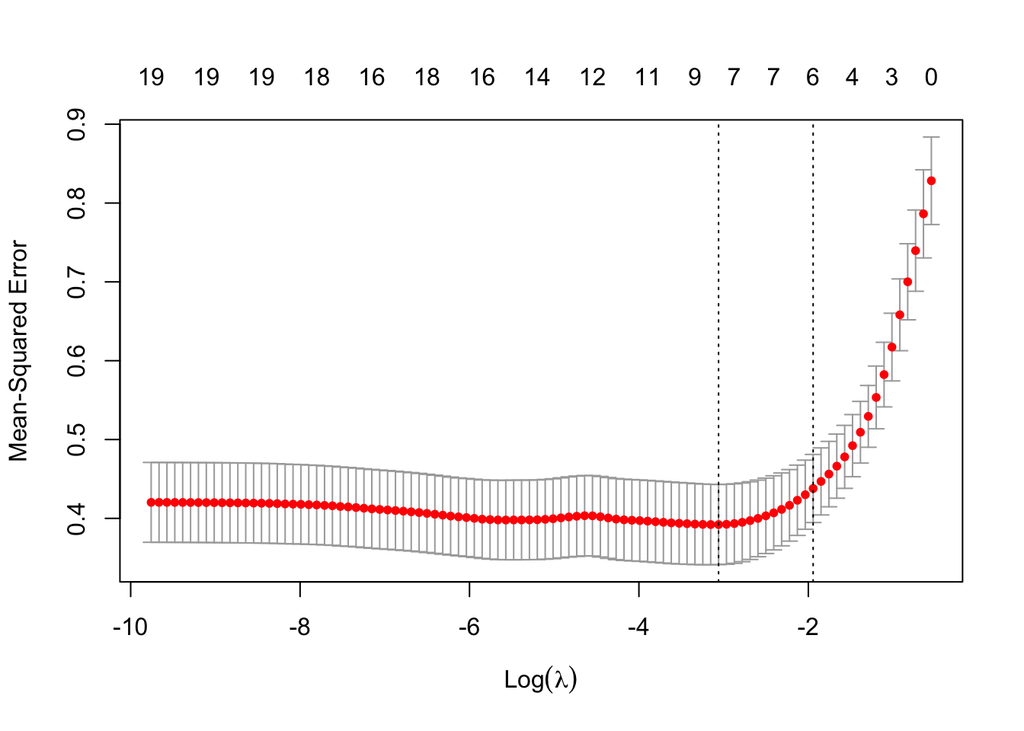

```r
hitters_lasso_cv <- cv.glmnet(x_train, y_train, alpha = 1)
plot(hitters_lasso_cv)
```

Best $\lambda$:

```r
lambda_opt <- hitters_lasso_cv$lambda.min

lasso_cv_pred_tr <- predict(hitters_lasso_cv, s = lambda_opt, x_train)
lasso_cv_mse_tr <- mean((lasso_cv_pred_tr - y_train)^2)

lasso_cv_pred_ts <- predict(hitters_lasso_cv, s = lambda_opt, x_test)
lasso_cv_mse_ts <- mean((lasso_cv_pred_ts - y_test)^2)
```

The training set MSE for an optimally-tuned LASSO regression model is 0.3572411 and the test set MSE is 0.450058, again both higher than that of the boosting approach.

This might suggest that the true relationship does not conform to a linear model and is more suitably approximated by non-linear models.

## Part (f)

Which variables appear to be the most important predictors in the boosted model?

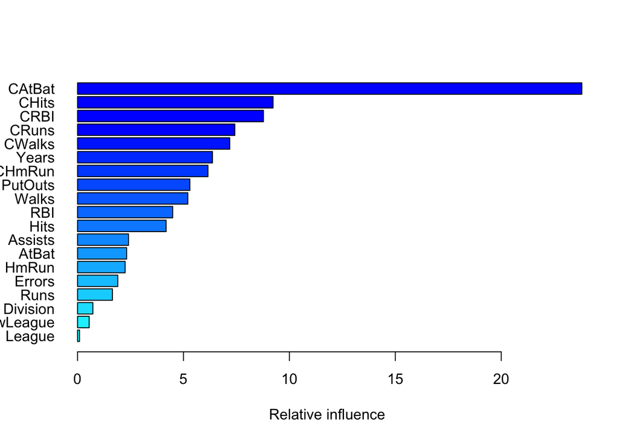

```
##                 var     rel_inf
## CAtBat       CAtBat 23.80511900
## CHits         CHits  9.22853112
## CRBI           CRBI  8.77325104
## CRuns         CRuns  7.42372962
## CWalks       CWalks  7.18535682
## Years         Years  6.36914666
## CHmRun       CHmRun  6.15669756
## PutOuts     PutOuts  5.30306689
## Walks         Walks  5.20390595
## RBI             RBI  4.49106166
## Hits           Hits  4.18079157
## Assists     Assists  2.40695824
## AtBat         AtBat  2.31900933
## HmRun         HmRun  2.24607335
## Errors       Errors  1.89887991
## Runs           Runs  1.64550388
## Division   Division  0.72288835
## NewLeague NewLeague  0.54795167
## League       League  0.09207736
```

```r
summary(hitters_boost)
```

## Part (g)

Now apply bagging to the training set. What is the test MSE for this approach?

```r
library(randomForest)

hitters_bagging <- randomForest(
  SalaryLog ~ . - Salary,
  data = train,
  mtry = 19
)

bagging_pred <- predict(hitters_bagging, test)
bagging_mse_ts <- mean((bagging_pred - test$SalaryLog)^2)
```

The MSE for bagging is 0.2336403, which is lower than the boosting test MSE.